# Penn Genomics Summer Bootcamp

Exercises: Gene Prioritzation

Published

July 31, 2024

```r
library(tidyverse)
library(vroom)
library(gwasRtools)
library(levinmisc)
```

## Variant-to-gene mapping

GWAS identify regions of the genome associated with a trait/disease of interest. However, most genetic variation doesn’t affect the coding sequence of genes. To better understand the biological mechanisms implicated by genetic variation, one approach is mapping variants to genes. This can be done using different methods, such as proximity-based methods (e.g. mapping variants to the nearest gene) or functional methods (e.g. using chromatin conformation data to map variants to genes). Here, we’ll focus on a few common approaches.

## Exercise 1: Mapping variants to the nearest gene

This approach should be are refresher from our prior lectures. Here, we’ll use the `gwasRtools` package to map variants to loci and their nearest genes. We’ll use the `arrow` package to read/filter our summary statistics without loading them all into memory

```r
# load genome-wide significant variants
cad_gws <- arrow::open_tsv_dataset("/project/damrauer_shared/Users/sabramow/CAD/METAL/cad_meta_GRCh38_metal-1.txt.gz") %>%
  filter(`P-value` < 5e-8) %>%
  collect() %>%
  janitor::clean_names()

# Identify loci and append nearest gene
cad_loci <- cad_gws %>%
  gwasRtools::get_loci(chr_col = "chromosome", pos_col = "position", beta_col = "effect", se_col = "std_err", p_col = "p_value", maf_col = "freq1", snp_col = "marker_name") %>%
  filter(lead == TRUE) %>%
  gwasRtools::get_nearest_gene(chr_col = "chromosome", pos_col = "position", snp_col = "marker_name", build = 38) %>%
  arrange(p_value)
```

```
Locus size (bases) = 5e+05
P-value threshold = 5e-08

N variants = 51710
N variants p<threshold = 51155
N loci = 531
Using human genome build 38
Getting nearest gene for 531 unique variants
```

```r
cad_loci %>%
  glimpse()
```

```
Rows: 531
Columns: 22
$ chromosome  <dbl> 6, 9, 6, 1, 19, 21, 19, 12, 2, 1, 15, 13, 4, 1, 12, 6, 10,…
$ position    <int> 160576086, 22098575, 12903725, 109274570, 44908822, 342215…
$ marker_name <chr> "6:160576086", "9:22098575", "6:12903725", "1:109274570", …
$ allele1     <chr> "a", "a", "a", "a", "t", "a", "t", "c", "a", "t", "t", "t"…
$ allele2     <chr> "t", "g", "g", "g", "c", "g", "c", "g", "c", "c", "c", "c"…
$ freq1       <dbl> 0.9383, 0.5373, 0.5901, 0.7848, 0.0752, 0.1301, 0.1105, 0.…
$ freq_se     <dbl> 0.0102, 0.0584, 0.0635, 0.0355, 0.0163, 0.0185, 0.0075, 0.…
$ effect      <dbl> -0.2715, -0.1573, -0.1012, 0.0895, -0.1280, 0.1018, -0.105…
$ std_err     <dbl> 0.0070, 0.0031, 0.0034, 0.0038, 0.0062, 0.0052, 0.0053, 0.…
$ p_value     <dbl> 0.000e+00, 0.000e+00, 4.860e-199, 1.700e-119, 2.350e-95, 6…
$ direction   <chr> "---??--", "-------", "---?---", "+++++++", "-------", "++…
$ het_i_sq    <dbl> 81.5, 94.4, 77.5, 24.1, 88.4, 0.0, 66.0, 93.7, 39.9, 66.6,…
$ het_chi_sq  <dbl> 21.674, 106.486, 22.267, 7.907, 51.704, 3.042, 11.750, 31.…
$ het_df      <int> 4, 6, 5, 6, 6, 4, 4, 2, 6, 6, 6, 6, 6, 2, 1, 6, 6, 2, 6, 6…
$ het_p_val   <dbl> 2.327e-04, 1.108e-20, 4.658e-04, 2.450e-01, 2.139e-09, 5.5…
$ ncase       <dbl> 338381, 380507, 350684, 379498, 373960, 342341, 346027, 80…
$ ncontrol    <dbl> 1564630, 1836340, 1652190, 1832400, 1823280, 1569800, 1569…
$ samplesize  <dbl> 1903020, 2216840, 2002870, 2211900, 2197240, 1912140, 1915…
$ locus       <dbl> 224, 270, 178, 18, 496, 517, 483, 368, 74, 35, 407, 383, 1…
$ lead        <lgl> TRUE, TRUE, TRUE, TRUE, TRUE, TRUE, TRUE, TRUE, TRUE, TRUE…
$ gene        <chr> "LPA", "AL359922.1", "PHACTR1", "CELSR2", "APOE", "MRPS6",…
$ dist        <dbl> -44604, 68981, -187171, -25031, -3031, 78492, -116509, -25…
```

## Exercise 2: Approximate Bayesian Fine-Mapping

Fine-mapping is an approach that allows us to prioritize the probability that any variant at a locus is causal. A simple form of fine-mapping, which relies on the Approximate Bayes Factor, follows an (unrealistic) assumption that there is a single causal variant at the locus of interest. An implementation of this approach is available in the `levinmisc` package, based on the method applied in Graham, et al. Nature 2021:

Graham, S.E., Clarke, S.L., Wu, KH.H. et al. The power of genetic diversity in genome-wide association studies of lipids. Nature 600, 675–679 (2021). https://doi.org/10.1038/s41586-021-04064-3

```r
# Extract all variants +/- 500kb of genome-wide significant variant
locus_extract <- function(sumstats_df, # df containing summary statistics
                          sumstats_chr_col = chromosome,
                          sumstats_pos_col = position,
                          locus_df, # df containing gws loci
                          locus_chr_col = chromosome,
                          locus_pos_col = position,
                          locus_size = 5e5) {
  locus_df <- locus_df %>%
    select(chromosome = {{ locus_chr_col }}, lead_pos = {{ locus_pos_col }}) %>%
    distinct(chromosome, lead_pos)

    sumstats_df %>%
      rename(chromosome = {{ sumstats_chr_col }}, position = {{ sumstats_pos_col }}) %>%
      mutate(chromosome = as.numeric(chromosome), position = as.numeric(position)) %>%
      inner_join(locus_df) %>%
      filter(between(position, lead_pos - locus_size / 2, lead_pos + locus_size / 2)) %>%
      collect() %>%
      mutate(locus_marker = glue::glue("{chromosome}:{lead_pos}")) %>%
      select(locus_marker, chromosome, lead_pos, everything())
}

read_and_extract_locus <- function(sumstats_file, locus_df, ...) {
  vroom::vroom(sumstats_file, id = "filename") %>%
    locus_extract(locus_df = locus_df, ...)
}

cad_locus_top5 <- read_and_extract_locus(sumstats_file = "/project/damrauer_shared/Users/sabramow/CAD/METAL/cad_meta_GRCh38_metal-1.txt.gz",
                       sumstats_chr_col = Chromosome,
                       sumstats_pos_col = Position,
                       locus_df = cad_loci %>% head(5),
                       locus_chr_col = chromosome,
                       locus_pos_col = position,
                       locus_size = 5e5)

cad_locus_top5 %>%
  glimpse()
```

```
Rows: 29,447
Columns: 21
$ locus_marker <glue> "6:160576086", "1:109274570", "1:109274570", "1:10927457…
$ chromosome   <dbl> 6, 1, 1, 1, 9, 19, 6, 19, 9, 9, 6, 1, 6, 19, 6, 9, 6, 9, …
$ lead_pos     <int> 160576086, 109274570, 109274570, 109274570, 22098575, 449…
$ filename     <chr> "/project/damrauer_shared/Users/sabramow/CAD/METAL/cad_me…
$ position     <dbl> 160524959, 109065268, 109155578, 109172980, 22090604, 446…
$ MarkerName   <time> NA, NA, NA, NA, NA, NA, NA, NA, NA, NA, NA, NA, NA, NA, …
$ Allele1      <chr> "t", "t", "a", "a", "t", "a", "a", "a", "t", "a", "t", "c…
$ Allele2      <chr> "c", "c", "t", "c", "c", "g", "g", "g", "c", "g", "c", "c…
$ Freq1        <dbl> 0.9963, 0.9871, 0.9647, 0.0261, 0.4967, 0.9386, 0.9975, 0…
$ FreqSE       <dbl> 0.0000, 0.0000, 0.0000, 0.0000, 0.0647, 0.0068, 0.0000, 0…
$ Effect       <dbl> 0.0319, -0.0171, 0.0082, 0.0092, 0.1500, -0.0180, 0.0713,…
$ StdErr       <dbl> 0.0604, 0.0431, 0.0372, 0.0414, 0.0034, 0.0073, 0.0819, 0…
$ `P-value`    <dbl> 5.978e-01, 6.918e-01, 8.255e-01, 8.241e-01, 2.290e-305, 1…
$ Direction    <chr> "??+????", "???-???", "?????+?", "?????+?", "+++++-+", "-…
$ HetISq       <dbl> 0.0, 0.0, 0.0, 0.0, 97.0, 6.7, 0.0, 0.0, 0.0, 0.0, 23.7, …
$ HetChiSq     <dbl> 0.000, 0.000, 0.000, 0.000, 199.821, 4.286, 0.000, 0.000,…
$ HetDf        <dbl> 0, 0, 0, 0, 6, 4, 0, 0, 0, 1, 2, 0, 1, 0, 5, 6, 0, 4, 0, …
$ HetPVal      <dbl> 1.000e+00, 1.000e+00, 1.000e+00, 1.000e+00, 2.072e-40, 3.…
$ NCASE        <dbl> 98456, 29319, 17202, 17202, 358175, 331950, 47550, 80569,…
$ NCONTROL     <dbl> 823778, 183134, 59507, 59507, 1803920, 1556980, 313400, 8…
$ SAMPLESIZE   <dbl> 922234, 212453, 76709, 76709, 2162090, 1888920, 360950, 8…
```

```r
cad_locus_top5 %>%
  count(locus_marker)
```

```
# A tibble: 5 × 2
  locus_marker     n
  <glue>       <int>
1 19:44908822   6417
2 1:109274570   5349
3 6:12903725    5424
4 6:160576086   6205
5 9:22098575    6052
```

Now, we can perform Approximate Bayes Factor fine-mapping:

```r
cad_top5_abf <- cad_locus_top5 %>%
  mutate(n_effective = (4/(1/NCASE + 1/NCONTROL))) %>% # should probably use sum of effective sample sizes
  levinmisc::calc_credset(locus_marker_col = locus_marker, effect_col = Effect, se_col = StdErr, samplesize_col = n_effective, cred_interval = 0.95)
```

We see that at 3 of the loci we’ve narrowed the credible sets to a single variant, while at the other 2 (LPA and 9p21) there are still several thousand variants:

```r
cad_top5_abf %>%
  count(locus_marker)
```

```
# A tibble: 5 × 2
  locus_marker     n
  <glue>       <int>
1 19:44908822      1
2 1:109274570      1
3 6:12903725       1
4 6:160576086   6201
5 9:22098575    5985
```

If we create regional association plots, we see that this is because the LPA and 9p21 loci have multiple signals that are equivalently strong:

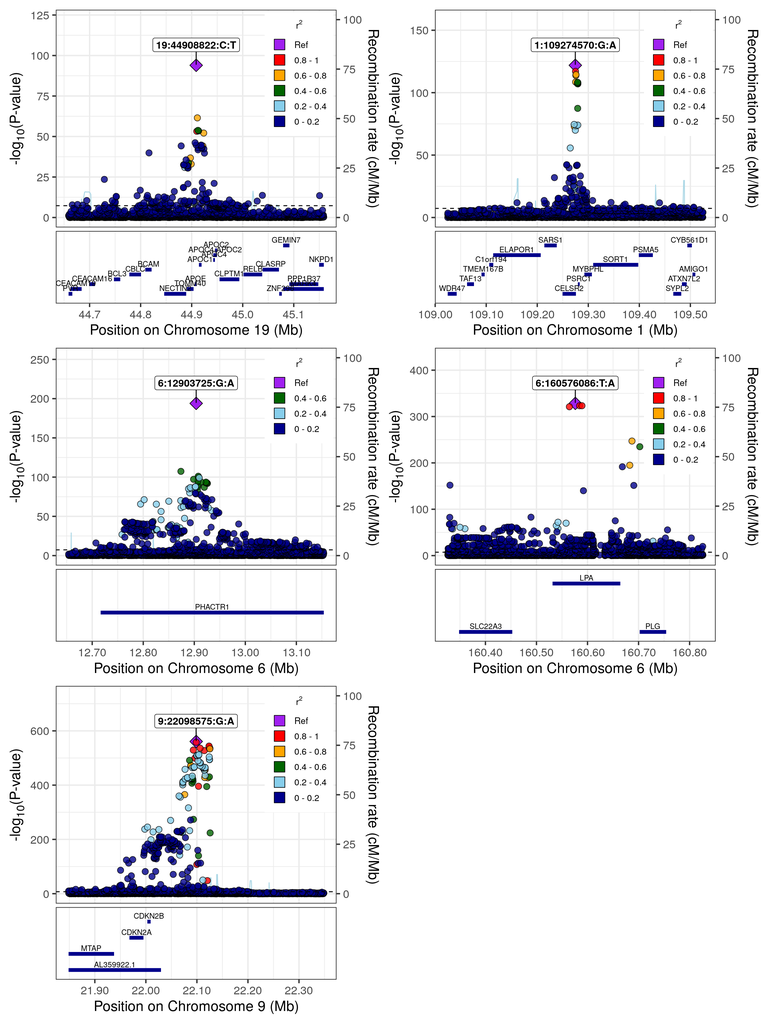

```r
locus_plots <- cad_locus_top5 %>%
  janitor::clean_names() %>%
  mutate(across(.cols = c(allele1, allele2), ~str_to_upper(.x))) %>% # make sure alleles are capitalized
  mutate(marker_id = glue::glue("{chromosome}:{position}:{allele2}:{allele1}")) %>% # give each variant a unique ID (could use rsid instead)
  group_nest(locus_marker) %>%
  mutate(locus_plot = map(data, ~locusplotr::gg_locusplot(df = .x, rsid = marker_id, chrom = chromosome, pos = position, effect = effect, std_err = std_err, ref = allele1, alt = allele2, plot_genes = TRUE, plot_recombination = TRUE, genome_build = "GRCh38")))

locus_plots %>%
  pull(locus_plot) %>%
  patchwork::wrap_plots(ncol = 2)
```

## Exercise 3: Annotating with OpenTargets data

OpenTargets is a platform that integrates genetics, genomics, and drug data to aid in the identification and prioritization of drug targets. OpenTargets maintains a database of useful annotations, which we can use to further annotate our credible sets.

```r
# Function to annotate variants with OpenTargets data
opentargets_annotate_consequence <- function(df, chr_col = chromosome, pos_col = position, effect_allele = Allele1, other_allele = Allele2, opentargets_index = "/project/voltron/Resources/OpenTargets/variant-index/", genome_build = "GRCh38") {

  checkmate::assert_choice(genome_build, choices = c("GRCh37", "GRCh38"))

  df <- df %>%
    select(chromosome = {{ chr_col }}, position = {{ pos_col }}, effect_allele = {{ effect_allele }}, other_allele = {{ other_allele }}, everything()) %>%
    mutate(chromosome = as.character(chromosome),
           position = as.integer(position)) %>%
    mutate(across(.cols = c(effect_allele, other_allele), ~str_to_upper(.x)))

  if(genome_build == "GRCh37") {
    opentargets_res <- arrow::open_dataset(opentargets_index) %>%
      select(rsid = rs_id, chromosome = chr_id_b37, position = position_b37, ref_allele, alt_allele, gene_id_prot_coding, most_severe_consequence) %>%
      right_join(df, by = c("chromosome", "position")) %>%
      collect()
  } else{
    opentargets_res <- arrow::open_dataset(opentargets_index) %>%
      select(rsid = rs_id, chromosome = chr_id, position = position, ref_allele, alt_allele, gene_id_prot_coding, most_severe_consequence) %>%
      right_join(df, by = c("chromosome", "position")) %>%
      collect()
  }

  # Match alleles
  opentargets_res %>%
    mutate(keep = case_when(
      (ref_allele == effect_allele & alt_allele == other_allele) ~ TRUE,
      (ref_allele == other_allele & alt_allele == effect_allele) ~ TRUE,
      TRUE ~ FALSE
    )) %>%
    filter(keep) %>%
    select(-ref_allele, -alt_allele, -effect_allele, -other_allele) %>%
    right_join(df) %>%
    select(-keep) %>%
    select(rsid, {{ chr_col }} := chromosome, {{ pos_col }} := position, {{ effect_allele }} := effect_allele, {{ other_allele }} := other_allele, gene_id_prot_coding, most_severe_consequence, everything())
}
```

Annotate our credible sets:

```r
cad_locus_top5_annotated <- cad_locus_top5 %>%
  opentargets_annotate_consequence()

cad_locus_top5_annotated %>%
  glimpse()
```

```
Rows: 29,726
Columns: 24
$ rsid                    <chr> "rs1347335849", "rs372385740", "rs149717088", …
$ chromosome              <chr> "1", "1", "1", "1", "1", "1", "1", "1", "1", "…
$ position                <int> 109061763, 109069644, 109084513, 109130249, 10…
$ Allele1                 <chr> "A", "A", "A", "T", "A", "A", "A", "A", "A", "…
$ Allele2                 <chr> "AATT", "T", "C", "TA", "ATT", "G", "T", "G", …
$ gene_id_prot_coding     <chr> "ENSG00000197780", "ENSG00000197780", "ENSG000…
$ most_severe_consequence <chr> "downstream_gene_variant", "intron_variant", "…
$ locus_marker            <glue> "1:109274570", "1:109274570", "1:109274570", …
$ lead_pos                <int> 109274570, 109274570, 109274570, 109274570, 10…
$ filename                <chr> "/project/damrauer_shared/Users/sabramow/CAD/M…
$ MarkerName              <time> NA, NA, NA, NA, NA, NA, NA, NA, NA, NA, NA, N…
$ Freq1                   <dbl> 0.0241, 0.9964, 0.9616, 0.9981, 0.9854, 0.0056…
$ FreqSE                  <dbl> 0.0091, 0.0009, 0.0100, 0.0007, 0.0000, 0.0017…
$ Effect                  <dbl> 0.0212, -0.0418, -0.0166, -0.0313, -0.0186, -0…
$ StdErr                  <dbl> 0.0219, 0.0651, 0.0101, 0.0858, 0.0337, 0.0394…
$ `P-value`               <dbl> 3.334e-01, 5.207e-01, 1.003e-01, 7.152e-01, 5.…
$ Direction               <chr> "?+-????", "--?????", "+?-??--", "?+-????", "?…
$ HetISq                  <dbl> 0.0, 45.3, 70.0, 31.4, 0.0, 0.0, 0.0, 1.5, 26.…
$ HetChiSq                <dbl> 0.234, 1.827, 9.988, 1.458, 0.000, 0.238, 0.00…
$ HetDf                   <dbl> 1, 1, 3, 1, 0, 1, 0, 6, 6, 0, 0, 4, 1, 0, 6, 0…
$ HetPVal                 <dbl> 0.628700, 0.176500, 0.018660, 0.227200, 1.0000…
$ NCASE                   <dbl> 128119, 142701, 290238, 107088, 47550, 147805,…
$ NCONTROL                <dbl> 1128330, 510687, 1252500, 819221, 313400, 1139…
$ SAMPLESIZE              <dbl> 1256450, 653388, 1542740, 926309, 360950, 1287…
```

```r
cad_locus_top5_annotated %>%
  count(most_severe_consequence)
```

```
# A tibble: 20 × 2
   most_severe_consequence                n
   <chr>                              <int>
 1 3_prime_UTR_variant                  509
 2 5_prime_UTR_variant                  125
 3 TF_binding_site_variant                7
 4 downstream_gene_variant              878
 5 frameshift_variant                     1
 6 inframe_deletion                       4
 7 inframe_insertion                      7
 8 intergenic_variant                  4362
 9 intron_variant                     15910
10 missense_variant                     296
11 non_coding_transcript_exon_variant   545
12 regulatory_region_variant            545
13 splice_acceptor_variant                6
14 splice_donor_variant                   8
15 splice_region_variant                 67
16 stop_gained                            6
17 stop_retained_variant                  1
18 synonymous_variant                   198
19 upstream_gene_variant               1448
20 <NA>                                4803
```

## Exercise 4: MAGMA

MAGMA is a tool that can be used for gene-based analysis of GWAS summary statistics:

de Leeuw CA, Mooij JM, Heskes T, Posthuma D (2015) MAGMA: Generalized Gene-Set Analysis of GWAS Data. PLoS Comput Biol 11(4): e1004219. https://doi.org/10.1371/journal.pcbi.1004219

The `levinmisc` package has a function to run MAGMA. We’ll use this on chromosome 10 as an example:

```r
cad_sumstats <- vroom::vroom("/project/damrauer_shared/Users/sabramow/CAD/METAL/cad_meta_GRCh38_metal-1.txt.gz")

cad_sumstats_annotated <- cad_sumstats %>%
  filter(Chromosome == 10) %>%
  levinmisc::annotate_rsids(chrom_col = Chromosome, pos_col = Position, dbSNP = SNPlocs.Hsapiens.dbSNP144.GRCh38::SNPlocs.Hsapiens.dbSNP144.GRCh38)

cad_sumstats_annotated %>%
  glimpse()
```

```
Rows: 1,622,498
Columns: 19
$ rsid       <chr> "rs757549956", "rs2339899", "rs769877968", "rs772228111", "…
$ Chromosome <dbl> 10, 10, 10, 10, 10, 10, 10, 10, 10, 10, 10, 10, 10, 10, 10,…
$ Position   <int> 86741807, 51948972, 71021067, 58032930, 66497277, 53007022,…
$ MarkerName <time> NA, NA, NA, NA, NA, NA, NA, NA, NA, NA, NA, NA, NA, NA, NA…
$ Allele1    <chr> "a", "a", "t", "t", "a", "t", "a", "t", "a", "t", "c", "t",…
$ Allele2    <chr> "g", "g", "c", "c", "g", "c", "g", "c", "c", "c", "g", "c",…
$ Freq1      <dbl> 0.0027, 0.7737, 0.0002, 0.0007, 0.9997, 0.9947, 0.0006, 0.0…
$ FreqSE     <dbl> 0.0006, 0.0419, 0.0000, 0.0000, 0.0000, 0.0016, 0.0000, 0.0…
$ Effect     <dbl> 0.0592, 0.0019, 0.0375, 0.0027, -0.1469, 0.0009, -0.1534, -…
$ StdErr     <dbl> 0.0997, 0.0037, 0.3768, 0.1631, 0.2313, 0.0367, 0.1696, 0.0…
$ P.value    <dbl> 0.5527000, 0.5986000, 0.9207000, 0.9868000, 0.5255000, 0.98…
$ Direction  <chr> "?++????", "+--+-++", "?+?????", "??+????", "?-?????", "-++…
$ HetISq     <dbl> 0.0, 8.6, 0.0, 0.0, 0.0, 0.0, 0.0, 0.0, 0.0, 0.0, 0.0, 0.0,…
$ HetChiSq   <dbl> 0.396, 6.566, 0.000, 0.000, 0.000, 1.020, 0.000, 0.000, 0.0…
$ HetDf      <dbl> 1, 6, 0, 0, 0, 2, 0, 0, 0, 0, 0, 6, 0, 0, 6, 6, 0, 1, 4, 6,…
$ HetPVal    <dbl> 0.5289, 0.3628, 1.0000, 1.0000, 1.0000, 0.6005, 1.0000, 1.0…
$ NCASE      <dbl> 120409, 378893, 47550, 59538, 47550, 242956, 90746, 17202, …
$ NCONTROL   <dbl> 1069750, 1836050, 313400, 505821, 313400, 1337250, 765201, …
$ SAMPLESIZE <dbl> 1190160, 2214940, 360950, 565359, 360950, 1580200, 855947, …
```

```r
cad_magma_res <- cad_sumstats_annotated %>%
  levinmisc::magmar(
    snp_col = rsid,
    pval_col = P.value,
    samplesize_col = SAMPLESIZE,
    magma_bin = "/project/voltron/Applications/magma_v1.10/magma",
    bfile = "/project/voltron/Resources/1000-Genomes-Phase3/MAGMA-1kg/g1000_eur",
    gene_file = "/project/voltron/Resources/MAGMA/NCBI37/NCBI37.genes.annot",
    out_file = "/project/damrauer_shared/Users/mglevin/Penn/project/damrauer_shared/Users/mglevin/Penn-Genomics-Bootcamp/Results/cad_magma_res"
  )
```

```
Running /project/voltron/Applications/magma_v1.10/magma --bfile \
  /project/voltron/Resources/1000-Genomes-Phase3/MAGMA-1kg/g1000_eur \
  --gene-annot /project/voltron/Resources/MAGMA/NCBI37/NCBI37.genes.annot \
  --pval /tmp/RtmpfbrzZX/file32a1e30fe19b5 'ncol=N' --gene-model \
  'snp-wise=mean' --out \
  /project/damrauer_shared/Users/mglevin/Penn/project/damrauer_shared/Users/mglevin/Penn-Genomics-Bootcamp/Results/cad_magma_res
Welcome to MAGMA v1.10 (linux)
Using flags:
    --bfile /project/voltron/Resources/1000-Genomes-Phase3/MAGMA-1kg/g1000_eur
    --gene-annot /project/voltron/Resources/MAGMA/NCBI37/NCBI37.genes.annot
    --pval /tmp/RtmpfbrzZX/file32a1e30fe19b5 ncol=N
    --gene-model snp-wise=mean
    --out /project/damrauer_shared/Users/mglevin/Penn/project/damrauer_shared/Users/mglevin/Penn-Genomics-Bootcamp/Results/cad_magma_res

Start time is 22:37:43, Tuesday 30 Jul 2024

Loading PLINK-format data...
Reading file /project/voltron/Resources/1000-Genomes-Phase3/MAGMA-1kg/g1000_eur.fam... 503 individuals read
Reading file /project/voltron/Resources/1000-Genomes-Phase3/MAGMA-1kg/g1000_eur.bim... 22665064 SNPs read
Preparing file /project/voltron/Resources/1000-Genomes-Phase3/MAGMA-1kg/g1000_eur.bed...

Reading SNP synonyms from file /project/voltron/Resources/1000-Genomes-Phase3/MAGMA-1kg/g1000_eur.synonyms (auto-detected)
    read 6016767 mapped synonyms from file, mapping to 3921040 SNPs in the data
    WARNING: detected 133 synonymous SNP pairs in the data
             skipped all synonym entries involved, synonymous SNPs are kept in analysis
             writing list of detected synonyms in data to supplementary log file
Reading SNP p-values from file /tmp/RtmpfbrzZX/file32a1e30fe19b5...
    detected 3 variables in file
    using variable: SNP (SNP id)
    using variable: P (p-value)
    using variable: N (sample size; discarding SNPs with N < 50)
    read 1622499 lines from file, containing valid SNP p-values for 793365 SNPs in data (48.9% of lines, 3.5% of SNPs in data)
    WARNING: file contained 1 SNP (same ID or synonym) with duplications
             dropped all occurrences of each from analysis
             writing list of duplicated IDs to supplementary log file
Loading gene annotation from file /project/voltron/Resources/MAGMA/NCBI37/NCBI37.genes.annot...
    19248 gene definitions read from file
    found 718 genes containing valid SNPs in genotype data


```

[output cut: 42 more lines]

```
    processed genes: 562 (78.3%)
    processed genes: 572 (79.7%)
    processed genes: 589 (82%)
    processed genes: 611 (85.1%)
    processed genes: 639 (89%)
    processed genes: 645 (89.8%)
    processed genes: 673 (93.7%)
    processed genes: 683 (95.1%)
    processed genes: 696 (96.9%)

    writing gene analysis results to file /project/damrauer_shared/Users/mglevin/Penn/project/damrauer_shared/Users/mglevin/Penn-Genomics-Bootcamp/Results/cad_magma_res.genes.out
    writing intermediate output to file /project/damrauer_shared/Users/mglevin/Penn/project/damrauer_shared/Users/mglevin/Penn-Genomics-Bootcamp/Results/cad_magma_res.genes.raw


End time is 22:42:15, Tuesday 30 Jul 2024 (elapsed: 00:04:32)
```